# Google Stroe 應用程式下載類別分析

同意啦哪次不同意_Team1

# 同意啦哪次不同意_Team1

## (KDD1) 原生資料展示

> > 1. APP數據Row共 7684筆紀錄
> > 2. APP數據Col共 16筆紀錄
> > 3. 數據樣貌為:

| App | Category | Rating | Reviews | Size | Installs | Type | Price | Content Rating | Genres | Last Updated | Year | Month | Day | Current Ver | Android Ver |
| --- | --- | --- | --- | --- | --- | --- | --- | --- | --- | --- | --- | --- | --- | --- | --- |
| Photo Editor & Candy Camera & Grid & ScrapBook | ART_AND_DESIGN | 4.1 | 159 | 19M | 1e+04 | Free | 0 | Everyone | Art & Design | 2018-01-07 | 2018 | 1 | 7 | 1.0.0 | 4.0.3 and up |
| Coloring book moana | ART_AND_DESIGN | 3.9 | 967 | 14M | 5e+05 | Free | 0 | Everyone | Art & Design;Pretend Play | 2018-01-15 | 2018 | 1 | 15 | 2.0.0 | 4.0.3 and up |
| U Launcher Lite ??FREE Live Cool Themes, Hide Apps | ART_AND_DESIGN | 4.7 | 87510 | 8.7M | 5e+06 | Free | 0 | Everyone | Art & Design | 2018-08-01 | 2018 | 8 | 1 | 1.2.4 | 4.0.3 and up |
| Sketch - Draw & Paint | ART_AND_DESIGN | 4.5 | 215644 | 25M | 5e+07 | Free | 0 | Teen | Art & Design | 2018-06-08 | 2018 | 6 | 8 | Varies with device | 4.2 and up |

## (KDD2)

> > 資料區間[1] Rating 在 0-1 之間16筆

> > 資料區間[2] Rating 在 1-2 之間50筆

> > 資料區間[3] Rating 在 2-3 之間284筆

> > 資料區間[4] Rating 在 3-4 之間1923筆

> > 資料區間[5] Rating 在 4-5 之間5411筆

> > Rating 的直方分佈圖

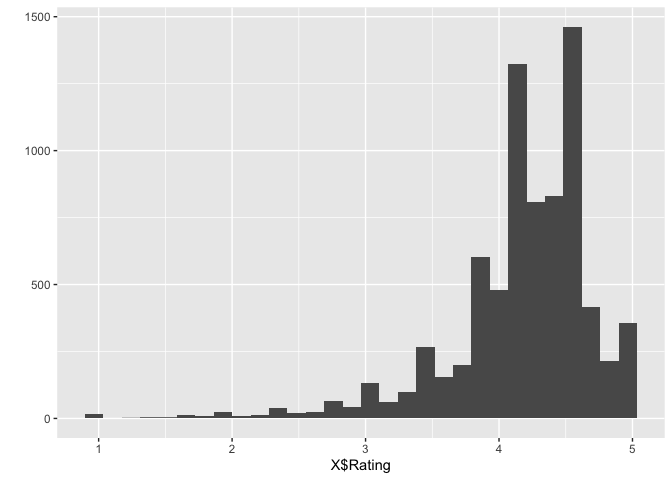

## (KDD3)

> > 在 ward.D 演算法下的分群分析

| X.group | Freq |
| --- | --- |
| 1 | 2703 |
| 2 | 487 |
| 3 | 525 |
| 4 | 115 |
| 5 | 1463 |
| 6 | 1294 |
| 7 | 542 |
| 8 | 282 |
| 9 | 52 |
| 10 | 69 |
| 11 | 20 |
| 12 | 10 |
| 13 | 32 |
| 14 | 6 |
| 15 | 4 |
| 16 | 34 |
| 17 | 4 |
| 18 | 10 |
| 19 | 28 |
| 20 | 4 |

## (KDD4)

```
## Reviews
##     145
```

```
##  Reviews
## 145.0067
```

|  |  | Rating | Reviews | Installs |
| --- | --- | --- | --- | --- |
| 1 | 2703 | 4 | 145 | 4647 |
| 5 | 1463 | 4 | 2570 | 85202 |
| 6 | 1294 | 4 | 33331 | 1000000 |
| 7 | 542 | 4 | 155650 | 10000000 |
| 3 | 525 | 4 | 106101 | 5000000 |
| 2 | 487 | 4 | 9484 | 500000 |
| 8 | 282 | 4 | 696882 | 10000000 |
| 4 | 115 | 4 | 889798 | 50000000 |
| 10 | 69 | 4 | 3652105 | 100000000 |
| 9 | 52 | 4 | 1104224 | 100000000 |
| 16 | 34 | 4 | 5831267 | 100000000 |
| 13 | 32 | 4 | 3116173 | 50000000 |
| 19 | 28 | 4 | 9132439 | 100000000 |
| 11 | 20 | 4 | 6571200 | 500000000 |
| 12 | 10 | 4 | 21013383 | 500000000 |
| 18 | 10 | 4 | 13838531 | 100000000 |
| 14 | 6 | 4 | 27721993 | 1000000000 |
| 15 | 4 | 5 | 23132574 | 100000000 |
| 17 | 4 | 5 | 44889695 | 100000000 |
| 20 | 4 | 4 | 877744 | 1000000000 |

## (KDD5)

> > (1)轉換成 Gfeature 的數據框（顯示前五筆）

| id | count | Rating | Reviews | Installs | feature |
| --- | --- | --- | --- | --- | --- |
| 1 | 2703 | 4.114058 | 145.0067 | 4646.566 | 4.11 * Rating+145.01 * Reviews+4646.57 * Installs |
| 2 | 487 | 4.166530 | 9483.6181 | 500000.000 | 4.17 * Rating+9483.62 * Reviews+5e+05 * Installs |
| 3 | 525 | 4.248952 | 106100.6076 | 5000000.000 | 4.25 * Rating+106100.61 * Reviews+5e+06 * Installs |
| 4 | 115 | 4.306957 | 889797.8348 | 50000000.000 | 4.31 * Rating+889797.83 * Reviews+5e+07 * Installs |
| 5 | 1463 | 4.087696 | 2570.0615 | 85201.640 | 4.09 * Rating+2570.06 * Reviews+85201.64 * Installs |

##— Rtech04 關聯性分析 —-

> > (1)我們採用 apriori 演算法

> > (2)支持度(support)：「規則」在資料內具有普遍性，也就是這些 A 跟 B 同時出現的機率多少

> > (3)信賴度(confidence)：「規則」要有一定的信心水準，也就是當購買 A 狀態下，也會購買 B 的條件機率

|  | lhs |  | rhs | support | confidence | coverage | lift | count |
| --- | --- | --- | --- | --- | --- | --- | --- | --- |
| [1] | {2012} | => | {2011} | 0.1666667 | 1 | 0.1666667 | 3.0 | 1 |
| [2] | {2012} | => | {2013} | 0.1666667 | 1 | 0.1666667 | 3.0 | 1 |
| [3] | {2012} | => | {2014} | 0.1666667 | 1 | 0.1666667 | 2.0 | 1 |
| [4] | {2012} | => | {2015} | 0.1666667 | 1 | 0.1666667 | 2.0 | 1 |
| [5] | {2012} | => | {2016} | 0.1666667 | 1 | 0.1666667 | 1.5 | 1 |
| [6] | {2012} | => | {2018} | 0.1666667 | 1 | 0.1666667 | 1.0 | 1 |
| [7] | {2012} | => | {2017} | 0.1666667 | 1 | 0.1666667 | 1.0 | 1 |
| [8] | {2011} | => | {2013} | 0.3333333 | 1 | 0.3333333 | 3.0 | 2 |
| [9] | {2013} | => | {2011} | 0.3333333 | 1 | 0.3333333 | 3.0 | 2 |
| [10] | {2011} | => | {2014} | 0.3333333 | 1 | 0.3333333 | 2.0 | 2 |
| [11] | {2011} | => | {2015} | 0.3333333 | 1 | 0.3333333 | 2.0 | 2 |
| [12] | {2011} | => | {2016} | 0.3333333 | 1 | 0.3333333 | 1.5 | 2 |
| [13] | {2011} | => | {2018} | 0.3333333 | 1 | 0.3333333 | 1.0 | 2 |
| [14] | {2011} | => | {2017} | 0.3333333 | 1 | 0.3333333 | 1.0 | 2 |
| [15] | {2013} | => | {2014} | 0.3333333 | 1 | 0.3333333 | 2.0 | 2 |
| [16] | {2013} | => | {2015} | 0.3333333 | 1 | 0.3333333 | 2.0 | 2 |
| [17] | {2013} | => | {2016} | 0.3333333 | 1 | 0.3333333 | 1.5 | 2 |
| [18] | {2013} | => | {2018} | 0.3333333 | 1 | 0.3333333 | 1.0 | 2 |
| [19] | {2013} | => | {2017} | 0.3333333 | 1 | 0.3333333 | 1.0 | 2 |
| [20] | {2014} | => | {2016} | 0.5000000 | 1 | 0.5000000 | 1.5 | 3 |
| [21] | {2014} | => | {2018} | 0.5000000 | 1 | 0.5000000 | 1.0 | 3 |
| [22] | {2014} | => | {2017} | 0.5000000 | 1 | 0.5000000 | 1.0 | 3 |
| [23] | {2015} | => | {2016} | 0.5000000 | 1 | 0.5000000 | 1.5 | 3 |
| [24] | {2015} | => | {2018} | 0.5000000 | 1 | 0.5000000 | 1.0 | 3 |
| [25] | {2015} | => | {2017} | 0.5000000 | 1 | 0.5000000 | 1.0 | 3 |
| [26] | {2016} | => | {2018} | 0.6666667 | 1 | 0.6666667 | 1.0 | 4 |
| [27] | {2016} | => | {2017} | 0.6666667 | 1 | 0.6666667 | 1.0 | 4 |
| [28] | {2018} | => | {2017} | 1.0000000 | 1 | 1.0000000 | 1.0 | 6 |
| [29] | {2017} | => | {2018} | 1.0000000 | 1 | 1.0000000 | 1.0 | 6 |

> > lhs=>rhs 代表左邊有，右邊也有的意思（普遍性與信心水準）

> > 總結： 中心點年份與個年份的關聯性最多

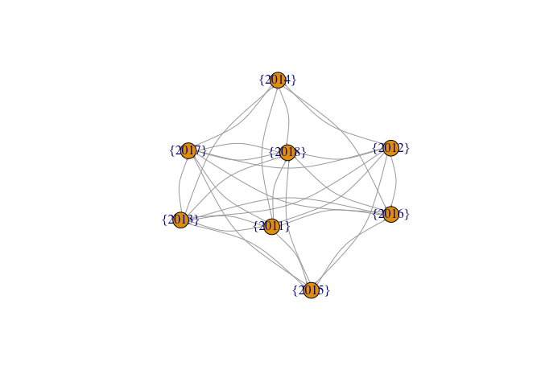

##———-以下測試用代碼 ————–

## ggplt

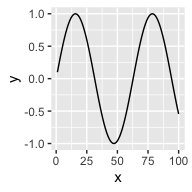

```r
library(ggplot2)
ggplot(data=data.frame(x=c(1:100),y=sin(0.1*c(1:100)))) +
geom_line(aes(x=x,y=y))
```